# K-Means Clustering

Prajwal C N

18/03/2021

#### Loading R libraries

```r
library(readr)
library(dplyr)
library(caret)
library(factoextra)
library(ggplot2)
library(tidyverse)
library(cowplot)
```

#### Importing the Pharmaceuticals dataset

```r
Pharmaceuticals <- read_csv("Pharmaceuticals.csv")

# Examining the dataset
glimpse(Pharmaceuticals)
```

```
## Rows: 21
## Columns: 14
## $ Symbol                <chr> "ABT", "AGN", "AHM", "AZN", "AVE", "BAY", "BMY",~
## $ Name                  <chr> "Abbott Laboratories", "Allergan, Inc.", "Amersh~
## $ Market_Cap            <dbl> 68.44, 7.58, 6.30, 67.63, 47.16, 16.90, 51.33, 0~
## $ Beta                  <dbl> 0.32, 0.41, 0.46, 0.52, 0.32, 1.11, 0.50, 0.85, ~
## $ PE_Ratio              <dbl> 24.7, 82.5, 20.7, 21.5, 20.1, 27.9, 13.9, 26.0, ~
## $ ROE                   <dbl> 26.4, 12.9, 14.9, 27.4, 21.8, 3.9, 34.8, 24.1, 1~
## $ ROA                   <dbl> 11.8, 5.5, 7.8, 15.4, 7.5, 1.4, 15.1, 4.3, 5.1, ~
## $ Asset_Turnover        <dbl> 0.7, 0.9, 0.9, 0.9, 0.6, 0.6, 0.9, 0.6, 0.3, 0.6~
## $ Leverage              <dbl> 0.42, 0.60, 0.27, 0.00, 0.34, 0.00, 0.57, 3.51, ~
## $ Rev_Growth            <dbl> 7.54, 9.16, 7.05, 15.00, 26.81, -3.17, 2.70, 6.3~
## $ Net_Profit_Margin     <dbl> 16.1, 5.5, 11.2, 18.0, 12.9, 2.6, 20.6, 7.5, 13.~
## $ Median_Recommendation <chr> "Moderate Buy", "Moderate Buy", "Strong Buy", "M~
## $ Location              <chr> "US", "CANADA", "UK", "UK", "FRANCE", "GERMANY",~
## $ Exchange              <chr> "NYSE", "NYSE", "NYSE", "NYSE", "NYSE", "NYSE", ~
```

```r
# Summary of Pharmaceuticals dataset
summary(Pharmaceuticals)
```

```
##     Symbol              Name             Market_Cap          Beta
##  Length:21          Length:21          Min.   :  0.41   Min.   :0.1800
##  Class :character   Class :character   1st Qu.:  6.30   1st Qu.:0.3500
##  Mode  :character   Mode  :character   Median : 48.19   Median :0.4600
##                                        Mean   : 57.65   Mean   :0.5257
##                                        3rd Qu.: 73.84   3rd Qu.:0.6500
##                                        Max.   :199.47   Max.   :1.1100
##     PE_Ratio          ROE            ROA        Asset_Turnover    Leverage
##  Min.   : 3.60   Min.   : 3.9   Min.   : 1.40   Min.   :0.3    Min.   :0.0000
##  1st Qu.:18.90   1st Qu.:14.9   1st Qu.: 5.70   1st Qu.:0.6    1st Qu.:0.1600
##  Median :21.50   Median :22.6   Median :11.20   Median :0.6    Median :0.3400
##  Mean   :25.46   Mean   :25.8   Mean   :10.51   Mean   :0.7    Mean   :0.5857
##  3rd Qu.:27.90   3rd Qu.:31.0   3rd Qu.:15.00   3rd Qu.:0.9    3rd Qu.:0.6000
##  Max.   :82.50   Max.   :62.9   Max.   :20.30   Max.   :1.1    Max.   :3.5100
##    Rev_Growth    Net_Profit_Margin Median_Recommendation   Location
##  Min.   :-3.17   Min.   : 2.6      Length:21             Length:21
##  1st Qu.: 6.38   1st Qu.:11.2      Class :character      Class :character
##  Median : 9.37   Median :16.1      Mode  :character      Mode  :character
##  Mean   :13.37   Mean   :15.7
##  3rd Qu.:21.87   3rd Qu.:21.1
##  Max.   :34.21   Max.   :25.5
##    Exchange
##  Length:21
##  Class :character
##  Mode  :character
##
##
##
```

#### Data cleaning and Scaling

*Q1:* Justifying the various choices made in conducting the cluster analysis, such as weights for different variables, the specific clustering algorithm(s)

```r
# Checking NULL values in the dataset at column level.
apply(Pharmaceuticals,2,function(x){any(is.na(x))})
```

```
##                Symbol                  Name            Market_Cap
##                 FALSE                 FALSE                 FALSE
##                  Beta              PE_Ratio                   ROE
##                 FALSE                 FALSE                 FALSE
##                   ROA        Asset_Turnover              Leverage
##                 FALSE                 FALSE                 FALSE
##            Rev_Growth     Net_Profit_Margin Median_Recommendation
##                 FALSE                 FALSE                 FALSE
##              Location              Exchange
##                 FALSE                 FALSE
```

```r
# Using only the numerical variables (1 to 9) for cluster analysis
Pharmaceuticals_1to9 <- Pharmaceuticals %>% select_if(is.numeric)

# Scaling the data frame (z-score).
set.seed(22)
scale_data <- as.data.frame(scale(Pharmaceuticals_1to9))
```

#### Estimating the optimal number of clusters.

Elbow Method and Silhouette Method on scale data

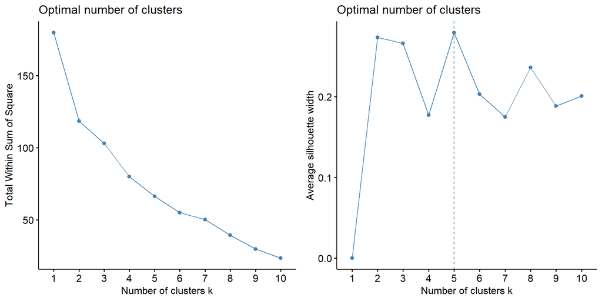

```r
wss1 <- fviz_nbclust(scale_data,FUNcluster = kmeans,method = "wss")
sil1 <- fviz_nbclust(scale_data,FUNcluster = kmeans,method = "silhouette")
plot_grid(wss1, sil1)
```

**From Eblow method best K is 2 and From Silhouette Method k is 5, There is a discrepancy in finding optimal number of clusters, may be due to outliers in data.**

So now finding optimal number of clusters, by handling the Outliers.

Finding IQR

```r
#Finding outliers
outlier_dectecion <- function(x,df = Pharmaceuticals_1to9){
  q1 = quantile(df[[x]],0.25) #25th Percentile
  q3 = quantile(df[[x]],0.75) #75th Percentile
  IQR = q3 - q1
  upper_bound = q3 + 1.5 * IQR
  lower_bound = q1 - 1.5 * IQR
  df[(df[x]<lower_bound) | (df[x]>upper_bound),x]
}

out <- vector('list', length(names(Pharmaceuticals_1to9)))


for (i in seq_along(Pharmaceuticals_1to9)){
  x1 <- outlier_dectecion(names(Pharmaceuticals_1to9)[i])
  out[[i]] <- x1
}

names(out) <- names(Pharmaceuticals_1to9)

AfterHandling_outliers <- Pharmaceuticals_1to9 %>%
  filter(Market_Cap != out[[1]], Beta != out[[2]],
         !(PE_Ratio %in% out[[3]]), ROE != out[[4]], !(Leverage %in% out[[7]]))
```

Post handling outliers, Estimating the optimal number of clusters

Elbow Method and Silhouette Method

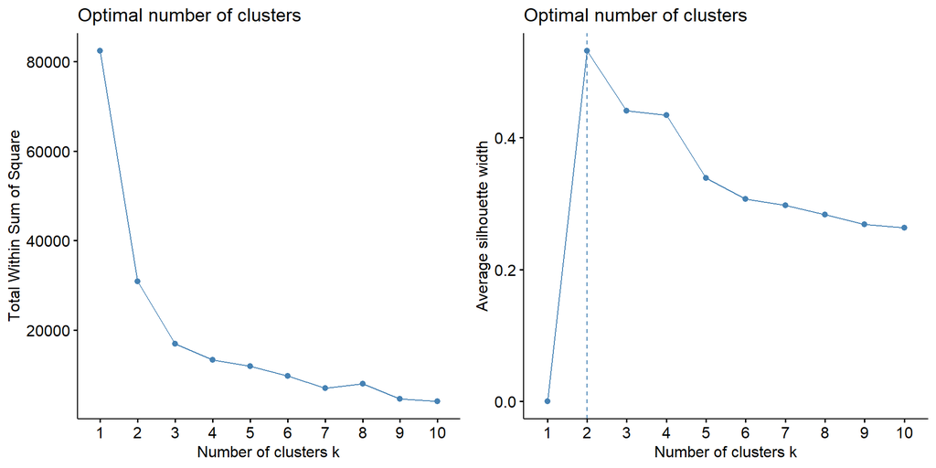

```r
wss2 <- fviz_nbclust(AfterHandling_outliers,FUNcluster = kmeans,method = "wss")
sil2 <- fviz_nbclust(AfterHandling_outliers,FUNcluster = kmeans,method = "silhouette")
plot_grid(wss2, sil2)
```

**Considering all the observations, We can clearly see that Silhouette Method is significantly affected by Outliers.So, taking number of clusters values to 2 and 3.**

**For Model building, Considered all the scaled data without omitting Outliers**

**K = 2**

```r
model_K2 <- kmeans(scale_data, centers = 2, nstart = 25)
model_K2
```

```
## K-means clustering with 2 clusters of sizes 11, 10
##
## Cluster means:
##   Market_Cap       Beta   PE_Ratio        ROE        ROA Asset_Turnover
## 1  0.6733825 -0.3586419 -0.2763512  0.6565978  0.8344159      0.4612656
## 2 -0.7407208  0.3945061  0.3039863 -0.7222576 -0.9178575     -0.5073922
##     Leverage Rev_Growth Net_Profit_Margin
## 1 -0.3331068 -0.2902163         0.6823310
## 2  0.3664175  0.3192379        -0.7505641
##
## Clustering vector:
##  [1] 1 2 2 1 2 2 1 2 2 1 1 2 1 2 1 1 1 2 1 2 1
##
## Within cluster sum of squares by cluster:
## [1] 43.30886 75.26049
##  (between_SS / total_SS =  34.1 %)
##
## Available components:
##
## [1] "cluster"      "centers"      "totss"        "withinss"     "tot.withinss"
## [6] "betweenss"    "size"         "iter"         "ifault"
```

**K = 3**

```r
model_K3 <- kmeans(scale_data, centers = 3, nstart = 25)
model_K3
```

```
## K-means clustering with 3 clusters of sizes 4, 6, 11
##
## Cluster means:
##   Market_Cap       Beta   PE_Ratio        ROE        ROA Asset_Turnover
## 1 -0.6125361  0.2698666  1.3143935 -0.9609057 -1.0174553      0.2306328
## 2 -0.8261772  0.4775991 -0.3696184 -0.5631589 -0.8514589     -0.9994088
## 3  0.6733825 -0.3586419 -0.2763512  0.6565978  0.8344159      0.4612656
##     Leverage Rev_Growth Net_Profit_Margin
## 1 -0.3592866 -0.5757385        -1.3784169
## 2  0.8502201  0.9158889        -0.3319956
## 3 -0.3331068 -0.2902163         0.6823310
##
## Clustering vector:
##  [1] 3 1 1 3 2 1 3 2 2 3 3 2 3 2 3 3 3 1 3 2 3
##
## Within cluster sum of squares by cluster:
## [1] 20.54199 32.14336 43.30886
##  (between_SS / total_SS =  46.7 %)
##
## Available components:
##
## [1] "cluster"      "centers"      "totss"        "withinss"     "tot.withinss"
## [6] "betweenss"    "size"         "iter"         "ifault"
```

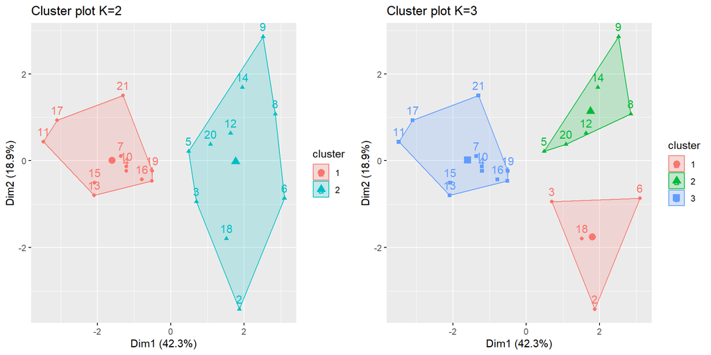

```r
K_2 <- fviz_cluster(model_K2,data = scale_data, main = 'Cluster plot K=2')
K_3 <- fviz_cluster(model_K3,data = scale_data, main = 'Cluster plot K=3')
plot_grid(K_2, K_3)
```

**Considering all the observations and visual analysis, I choose 3 as optimal k.**

*Q2:* Cluster analysis

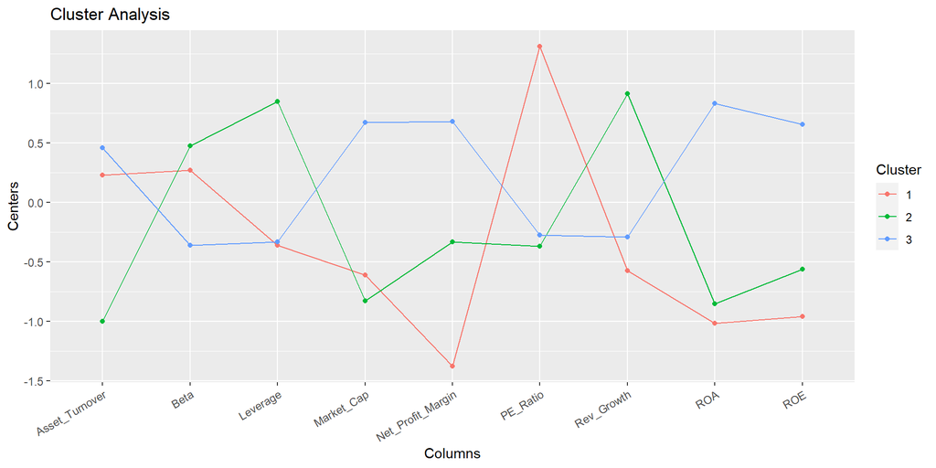

```r
clusters_centers <- data.frame(model_K3$centers) %>%
  rowid_to_column() %>%
  gather('Columns', 'Centers', -1)
ggplot(clusters_centers, aes(x = Columns, y = Centers, color = as.factor(rowid))) +
  geom_line(aes(group = as.factor(rowid))) + geom_point() +
  labs(color = "Cluster", title = 'Cluster Analysis') +
  theme(axis.text.x = element_text(angle = 30, hjust = 1, vjust = 1))
```

From the above graph we can infer that all cluster patterns are different, Please find below analysis for all 3 individual clusters.

1. **Cluster1 (Red)**: Companies fall under cluster1 has good Asset turnover and beta, But it’s leverage, market cap, Net profit margin, Rev Growth, ROA and ROE are low or underperforming when compare to other clusters, inspite of all this it has very good PE Ratio.
2. **Cluster2 (Green)**: Companies fall under cluster2 has low asset value(Asset turnover, ROA, ROE), But good revenue growth and also beta and leverage is better that other clusters.
3. **Cluster3 (Blue)**: Companies fall under cluster3 has very good Asset value(Asset turnover, ROA, ROE) and market cap, But lacks in Beta, Leverage, PE Ratio and Revenue Growth, Overall it has outstanding ROA compare to other clusters.

*Q3:* Applying above Cluster patterns applying to variables Median_Recommendation, Pharmaceuticals, Exchange

```r
(Pharmaceuticals_10to12 <-  Pharmaceuticals %>% select(c("Median_Recommendation","Location","Exchange")) %>%
  mutate(cluster_pattern = model_K3$cluster) %>% arrange(desc(cluster_pattern)))
```

```
## # A tibble: 21 x 4
##    Median_Recommendation Location    Exchange cluster_pattern
##    <chr>                 <chr>       <chr>              <int>
##  1 Moderate Buy          US          NYSE                   3
##  2 Moderate Sell         UK          NYSE                   3
##  3 Moderate Sell         US          NYSE                   3
##  4 Hold                  US          NYSE                   3
##  5 Hold                  UK          NYSE                   3
##  6 Moderate Buy          US          NYSE                   3
##  7 Hold                  US          NYSE                   3
##  8 Hold                  SWITZERLAND NYSE                   3
##  9 Moderate Buy          US          NYSE                   3
## 10 Hold                  US          NYSE                   3
## # ... with 11 more rows
```

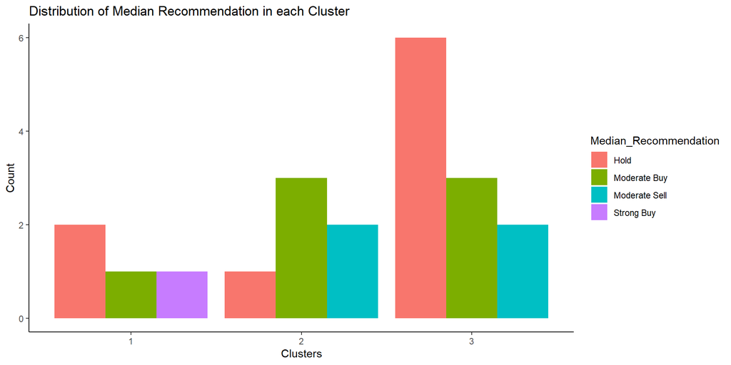

```r
ggplot(Pharmaceuticals_10to12, aes(fill = Median_Recommendation,
x = as.factor(cluster_pattern))) +
  geom_bar(position = 'dodge') +
labs(x="Clusters", y="Count",
     title = "Distribution of Median Recommendation in each Cluster") +
theme_classic()
```

From the above graph we can infer that **Cluster1** has strong buy option which is unique from other clusters and **Cluster2** has moderate buy and sell ratio equal to Cluster3 and **Cluster3** has good hold option compare to it’s peer clusters.

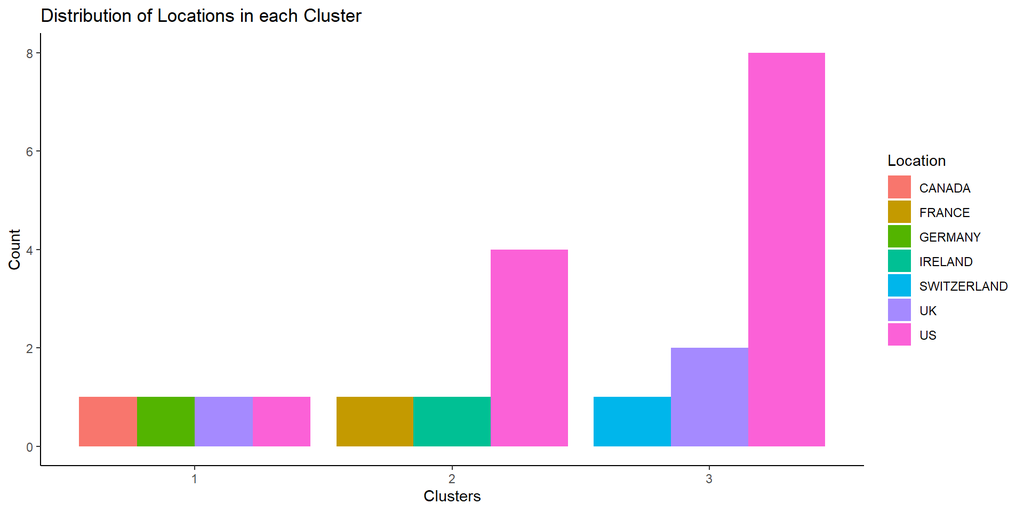

```r
ggplot(Pharmaceuticals_10to12, aes(fill = Location,
x = as.factor(cluster_pattern))) +
  geom_bar(position = 'dodge') +
labs(x="Clusters", y="Count",
     title = "Distribution of Locations in each Cluster") +
theme_classic()
```

**Cluster1** companies are in various countries such as Canada, Germany, UK, US also numbers are equally distributed, while **Cluster2** has companies located in France, Ireland and but has more companies in US, and **Cluster3** companies largerly located in US, some in UK and few in Switzerland.

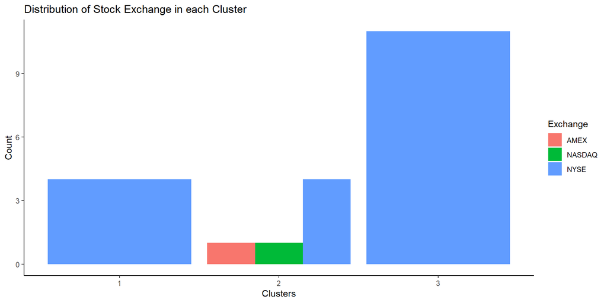

```r
ggplot(Pharmaceuticals_10to12, aes(fill = Exchange,
x = as.factor(cluster_pattern))) +
  geom_bar(position = 'dodge') +
labs(x="Clusters", y="Count",
     title = "Distribution of Stock Exchange in each Cluster") +
theme_classic()
```

All **Cluster1** and **Cluster3** companies fall under **NYSE** stock Exchange, While most **Cluster2** as well fall under **NYSE** stock Exchange but some companies operates under **AMEX** and **NASAQ**. Cluster2 is the only Cluster with AMEX and NASAQ stock Exchanges.

*Q4:* Providing an appropriate name for each cluster.

**Small Sized Pharmaceuticals Companies**: Cluster with High PE Ratio.

**Large Sized Pharmaceuticals Companies**: High Assets and Market cap Cluster.